# Risk Factor Analysis

## Outcome Variable

**Outcome Variable:** y_rate_wtkg

## Predictor Variables

**Intervention Variable:** safeh20

**Adjustment Set:**

unadjusted

## Stratifying Variables

The analysis was stratified on these variable(s):

- agecat
- studyid
- country

## Data Summary

| agecat | studyid | country | safeh20 | n_cell | n |
| --- | --- | --- | --- | --- | --- |
| 0-3 months | CONTENT | PERU | 1 | 5 | 6 |
| 0-3 months | CONTENT | PERU | 0 | 1 | 6 |
| 0-3 months | JiVitA-3 | BANGLADESH | 1 | 20238 | 20271 |
| 0-3 months | JiVitA-3 | BANGLADESH | 0 | 33 | 20271 |
| 0-3 months | JiVitA-4 | BANGLADESH | 1 | 1793 | 1793 |
| 0-3 months | JiVitA-4 | BANGLADESH | 0 | 0 | 1793 |
| 0-3 months | MAL-ED | BANGLADESH | 1 | 0 | 239 |
| 0-3 months | MAL-ED | BANGLADESH | 0 | 239 | 239 |
| 0-3 months | MAL-ED | BRAZIL | 1 | 0 | 142 |
| 0-3 months | MAL-ED | BRAZIL | 0 | 142 | 142 |
| 0-3 months | MAL-ED | INDIA | 1 | 0 | 232 |
| 0-3 months | MAL-ED | INDIA | 0 | 232 | 232 |
| 0-3 months | MAL-ED | NEPAL | 1 | 1 | 227 |
| 0-3 months | MAL-ED | NEPAL | 0 | 226 | 227 |
| 0-3 months | MAL-ED | PERU | 1 | 11 | 258 |
| 0-3 months | MAL-ED | PERU | 0 | 247 | 258 |
| 0-3 months | MAL-ED | SOUTH AFRICA | 1 | 38 | 251 |
| 0-3 months | MAL-ED | SOUTH AFRICA | 0 | 213 | 251 |
| 0-3 months | MAL-ED | TANZANIA, UNITED REPUBLIC OF | 1 | 158 | 232 |
| 0-3 months | MAL-ED | TANZANIA, UNITED REPUBLIC OF | 0 | 74 | 232 |
| 0-3 months | NIH-Birth | BANGLADESH | 1 | 563 | 565 |
| 0-3 months | NIH-Birth | BANGLADESH | 0 | 2 | 565 |
| 0-3 months | NIH-Crypto | BANGLADESH | 1 | 725 | 725 |
| 0-3 months | NIH-Crypto | BANGLADESH | 0 | 0 | 725 |
| 0-3 months | PROVIDE | BANGLADESH | 1 | 13 | 13 |
| 0-3 months | PROVIDE | BANGLADESH | 0 | 0 | 13 |
| 3-6 months | CONTENT | PERU | 1 | 54 | 57 |
| 3-6 months | CONTENT | PERU | 0 | 3 | 57 |
| 3-6 months | JiVitA-3 | BANGLADESH | 1 | 12701 | 12713 |
| 3-6 months | JiVitA-3 | BANGLADESH | 0 | 12 | 12713 |

[output cut: 182 more lines]

The following strata were considered:

- agecat: 0-3 months, studyid: CONTENT, country: PERU
- agecat: 0-3 months, studyid: JiVitA-3, country: BANGLADESH
- agecat: 0-3 months, studyid: JiVitA-4, country: BANGLADESH
- agecat: 0-3 months, studyid: MAL-ED, country: BANGLADESH
- agecat: 0-3 months, studyid: MAL-ED, country: BRAZIL
- agecat: 0-3 months, studyid: MAL-ED, country: INDIA
- agecat: 0-3 months, studyid: MAL-ED, country: NEPAL
- agecat: 0-3 months, studyid: MAL-ED, country: PERU
- agecat: 0-3 months, studyid: MAL-ED, country: SOUTH AFRICA
- agecat: 0-3 months, studyid: MAL-ED, country: TANZANIA, UNITED REPUBLIC OF
- agecat: 0-3 months, studyid: NIH-Birth, country: BANGLADESH
- agecat: 0-3 months, studyid: NIH-Crypto, country: BANGLADESH
- agecat: 0-3 months, studyid: PROVIDE, country: BANGLADESH
- agecat: 12-15 months, studyid: CONTENT, country: PERU
- agecat: 12-15 months, studyid: JiVitA-4, country: BANGLADESH
- agecat: 12-15 months, studyid: LCNI-5, country: MALAWI
- agecat: 12-15 months, studyid: MAL-ED, country: BANGLADESH
- agecat: 12-15 months, studyid: MAL-ED, country: BRAZIL
- agecat: 12-15 months, studyid: MAL-ED, country: INDIA
- agecat: 12-15 months, studyid: MAL-ED, country: NEPAL
- agecat: 12-15 months, studyid: MAL-ED, country: PERU
- agecat: 12-15 months, studyid: MAL-ED, country: SOUTH AFRICA
- agecat: 12-15 months, studyid: MAL-ED, country: TANZANIA, UNITED REPUBLIC OF
- agecat: 12-15 months, studyid: NIH-Birth, country: BANGLADESH
- agecat: 12-15 months, studyid: NIH-Crypto, country: BANGLADESH
- agecat: 12-15 months, studyid: PROVIDE, country: BANGLADESH
- agecat: 12-15 months, studyid: SAS-FoodSuppl, country: INDIA
- agecat: 15-18 months, studyid: CONTENT, country: PERU
- agecat: 15-18 months, studyid: JiVitA-4, country: BANGLADESH
- agecat: 15-18 months, studyid: LCNI-5, country: MALAWI
- agecat: 15-18 months, studyid: MAL-ED, country: BANGLADESH
- agecat: 15-18 months, studyid: MAL-ED, country: BRAZIL
- agecat: 15-18 months, studyid: MAL-ED, country: INDIA
- agecat: 15-18 months, studyid: MAL-ED, country: NEPAL
- agecat: 15-18 months, studyid: MAL-ED, country: PERU
- agecat: 15-18 months, studyid: MAL-ED, country: SOUTH AFRICA
- agecat: 15-18 months, studyid: MAL-ED, country: TANZANIA, UNITED REPUBLIC OF
- agecat: 15-18 months, studyid: NIH-Birth, country: BANGLADESH
- agecat: 15-18 months, studyid: NIH-Crypto, country: BANGLADESH
- agecat: 15-18 months, studyid: PROVIDE, country: BANGLADESH
- agecat: 15-18 months, studyid: SAS-FoodSuppl, country: INDIA
- agecat: 18-21 months, studyid: CONTENT, country: PERU
- agecat: 18-21 months, studyid: LCNI-5, country: MALAWI
- agecat: 18-21 months, studyid: MAL-ED, country: BANGLADESH
- agecat: 18-21 months, studyid: MAL-ED, country: BRAZIL
- agecat: 18-21 months, studyid: MAL-ED, country: INDIA
- agecat: 18-21 months, studyid: MAL-ED, country: NEPAL
- agecat: 18-21 months, studyid: MAL-ED, country: PERU
- agecat: 18-21 months, studyid: MAL-ED, country: SOUTH AFRICA
- agecat: 18-21 months, studyid: MAL-ED, country: TANZANIA, UNITED REPUBLIC OF
- agecat: 18-21 months, studyid: NIH-Birth, country: BANGLADESH
- agecat: 18-21 months, studyid: NIH-Crypto, country: BANGLADESH
- agecat: 18-21 months, studyid: PROVIDE, country: BANGLADESH
- agecat: 21-24 months, studyid: CONTENT, country: PERU
- agecat: 21-24 months, studyid: LCNI-5, country: MALAWI
- agecat: 21-24 months, studyid: MAL-ED, country: BANGLADESH
- agecat: 21-24 months, studyid: MAL-ED, country: BRAZIL
- agecat: 21-24 months, studyid: MAL-ED, country: INDIA
- agecat: 21-24 months, studyid: MAL-ED, country: NEPAL
- agecat: 21-24 months, studyid: MAL-ED, country: PERU
- agecat: 21-24 months, studyid: MAL-ED, country: SOUTH AFRICA
- agecat: 21-24 months, studyid: MAL-ED, country: TANZANIA, UNITED REPUBLIC OF
- agecat: 21-24 months, studyid: NIH-Birth, country: BANGLADESH
- agecat: 21-24 months, studyid: NIH-Crypto, country: BANGLADESH
- agecat: 21-24 months, studyid: PROVIDE, country: BANGLADESH
- agecat: 3-6 months, studyid: CONTENT, country: PERU
- agecat: 3-6 months, studyid: JiVitA-3, country: BANGLADESH
- agecat: 3-6 months, studyid: JiVitA-4, country: BANGLADESH
- agecat: 3-6 months, studyid: MAL-ED, country: BANGLADESH
- agecat: 3-6 months, studyid: MAL-ED, country: BRAZIL
- agecat: 3-6 months, studyid: MAL-ED, country: INDIA
- agecat: 3-6 months, studyid: MAL-ED, country: NEPAL
- agecat: 3-6 months, studyid: MAL-ED, country: PERU
- agecat: 3-6 months, studyid: MAL-ED, country: SOUTH AFRICA
- agecat: 3-6 months, studyid: MAL-ED, country: TANZANIA, UNITED REPUBLIC OF
- agecat: 3-6 months, studyid: NIH-Birth, country: BANGLADESH
- agecat: 3-6 months, studyid: NIH-Crypto, country: BANGLADESH
- agecat: 3-6 months, studyid: PROVIDE, country: BANGLADESH
- agecat: 6-9 months, studyid: CONTENT, country: PERU
- agecat: 6-9 months, studyid: JiVitA-4, country: BANGLADESH
- agecat: 6-9 months, studyid: LCNI-5, country: MALAWI
- agecat: 6-9 months, studyid: MAL-ED, country: BANGLADESH
- agecat: 6-9 months, studyid: MAL-ED, country: BRAZIL
- agecat: 6-9 months, studyid: MAL-ED, country: INDIA
- agecat: 6-9 months, studyid: MAL-ED, country: NEPAL
- agecat: 6-9 months, studyid: MAL-ED, country: PERU
- agecat: 6-9 months, studyid: MAL-ED, country: SOUTH AFRICA
- agecat: 6-9 months, studyid: MAL-ED, country: TANZANIA, UNITED REPUBLIC OF
- agecat: 6-9 months, studyid: NIH-Birth, country: BANGLADESH
- agecat: 6-9 months, studyid: NIH-Crypto, country: BANGLADESH
- agecat: 6-9 months, studyid: PROVIDE, country: BANGLADESH
- agecat: 6-9 months, studyid: SAS-FoodSuppl, country: INDIA
- agecat: 9-12 months, studyid: CONTENT, country: PERU
- agecat: 9-12 months, studyid: JiVitA-4, country: BANGLADESH
- agecat: 9-12 months, studyid: LCNI-5, country: MALAWI
- agecat: 9-12 months, studyid: MAL-ED, country: BANGLADESH
- agecat: 9-12 months, studyid: MAL-ED, country: BRAZIL
- agecat: 9-12 months, studyid: MAL-ED, country: INDIA
- agecat: 9-12 months, studyid: MAL-ED, country: NEPAL
- agecat: 9-12 months, studyid: MAL-ED, country: PERU
- agecat: 9-12 months, studyid: MAL-ED, country: SOUTH AFRICA
- agecat: 9-12 months, studyid: MAL-ED, country: TANZANIA, UNITED REPUBLIC OF
- agecat: 9-12 months, studyid: NIH-Birth, country: BANGLADESH
- agecat: 9-12 months, studyid: NIH-Crypto, country: BANGLADESH
- agecat: 9-12 months, studyid: PROVIDE, country: BANGLADESH
- agecat: 9-12 months, studyid: SAS-FoodSuppl, country: INDIA

### Dropped Strata

Some strata were dropped due to rare outcomes:

- agecat: 0-3 months, studyid: CONTENT, country: PERU
- agecat: 0-3 months, studyid: JiVitA-4, country: BANGLADESH
- agecat: 0-3 months, studyid: MAL-ED, country: BANGLADESH
- agecat: 0-3 months, studyid: MAL-ED, country: BRAZIL
- agecat: 0-3 months, studyid: MAL-ED, country: INDIA
- agecat: 0-3 months, studyid: MAL-ED, country: NEPAL
- agecat: 0-3 months, studyid: NIH-Birth, country: BANGLADESH
- agecat: 0-3 months, studyid: NIH-Crypto, country: BANGLADESH
- agecat: 0-3 months, studyid: PROVIDE, country: BANGLADESH
- agecat: 3-6 months, studyid: CONTENT, country: PERU
- agecat: 3-6 months, studyid: JiVitA-4, country: BANGLADESH
- agecat: 3-6 months, studyid: MAL-ED, country: BANGLADESH
- agecat: 3-6 months, studyid: MAL-ED, country: BRAZIL
- agecat: 3-6 months, studyid: MAL-ED, country: INDIA
- agecat: 3-6 months, studyid: MAL-ED, country: NEPAL
- agecat: 3-6 months, studyid: NIH-Birth, country: BANGLADESH
- agecat: 3-6 months, studyid: NIH-Crypto, country: BANGLADESH
- agecat: 3-6 months, studyid: PROVIDE, country: BANGLADESH
- agecat: 6-9 months, studyid: CONTENT, country: PERU
- agecat: 6-9 months, studyid: JiVitA-4, country: BANGLADESH
- agecat: 6-9 months, studyid: MAL-ED, country: BANGLADESH
- agecat: 6-9 months, studyid: MAL-ED, country: BRAZIL
- agecat: 6-9 months, studyid: MAL-ED, country: INDIA
- agecat: 6-9 months, studyid: MAL-ED, country: NEPAL
- agecat: 6-9 months, studyid: NIH-Birth, country: BANGLADESH
- agecat: 6-9 months, studyid: NIH-Crypto, country: BANGLADESH
- agecat: 6-9 months, studyid: PROVIDE, country: BANGLADESH
- agecat: 6-9 months, studyid: SAS-FoodSuppl, country: INDIA
- agecat: 9-12 months, studyid: CONTENT, country: PERU
- agecat: 9-12 months, studyid: JiVitA-4, country: BANGLADESH
- agecat: 9-12 months, studyid: MAL-ED, country: BANGLADESH
- agecat: 9-12 months, studyid: MAL-ED, country: BRAZIL
- agecat: 9-12 months, studyid: MAL-ED, country: INDIA
- agecat: 9-12 months, studyid: MAL-ED, country: NEPAL
- agecat: 9-12 months, studyid: NIH-Birth, country: BANGLADESH
- agecat: 9-12 months, studyid: NIH-Crypto, country: BANGLADESH
- agecat: 9-12 months, studyid: PROVIDE, country: BANGLADESH
- agecat: 9-12 months, studyid: SAS-FoodSuppl, country: INDIA
- agecat: 12-15 months, studyid: CONTENT, country: PERU
- agecat: 12-15 months, studyid: JiVitA-4, country: BANGLADESH
- agecat: 12-15 months, studyid: MAL-ED, country: BANGLADESH
- agecat: 12-15 months, studyid: MAL-ED, country: BRAZIL
- agecat: 12-15 months, studyid: MAL-ED, country: INDIA
- agecat: 12-15 months, studyid: MAL-ED, country: NEPAL
- agecat: 12-15 months, studyid: NIH-Birth, country: BANGLADESH
- agecat: 12-15 months, studyid: NIH-Crypto, country: BANGLADESH
- agecat: 12-15 months, studyid: PROVIDE, country: BANGLADESH
- agecat: 12-15 months, studyid: SAS-FoodSuppl, country: INDIA
- agecat: 15-18 months, studyid: CONTENT, country: PERU
- agecat: 15-18 months, studyid: JiVitA-4, country: BANGLADESH
- agecat: 15-18 months, studyid: MAL-ED, country: BANGLADESH
- agecat: 15-18 months, studyid: MAL-ED, country: BRAZIL
- agecat: 15-18 months, studyid: MAL-ED, country: INDIA
- agecat: 15-18 months, studyid: MAL-ED, country: NEPAL
- agecat: 15-18 months, studyid: NIH-Birth, country: BANGLADESH
- agecat: 15-18 months, studyid: NIH-Crypto, country: BANGLADESH
- agecat: 15-18 months, studyid: PROVIDE, country: BANGLADESH
- agecat: 15-18 months, studyid: SAS-FoodSuppl, country: INDIA
- agecat: 18-21 months, studyid: CONTENT, country: PERU
- agecat: 18-21 months, studyid: MAL-ED, country: BANGLADESH
- agecat: 18-21 months, studyid: MAL-ED, country: BRAZIL
- agecat: 18-21 months, studyid: MAL-ED, country: INDIA
- agecat: 18-21 months, studyid: MAL-ED, country: NEPAL
- agecat: 18-21 months, studyid: NIH-Birth, country: BANGLADESH
- agecat: 18-21 months, studyid: NIH-Crypto, country: BANGLADESH
- agecat: 18-21 months, studyid: PROVIDE, country: BANGLADESH
- agecat: 21-24 months, studyid: CONTENT, country: PERU
- agecat: 21-24 months, studyid: MAL-ED, country: BANGLADESH
- agecat: 21-24 months, studyid: MAL-ED, country: BRAZIL
- agecat: 21-24 months, studyid: MAL-ED, country: INDIA
- agecat: 21-24 months, studyid: MAL-ED, country: NEPAL
- agecat: 21-24 months, studyid: NIH-Birth, country: BANGLADESH
- agecat: 21-24 months, studyid: NIH-Crypto, country: BANGLADESH
- agecat: 21-24 months, studyid: PROVIDE, country: BANGLADESH

## Methods Detail

We’re interested in the causal parameters $E[Y_a]$ for all values of $a \in \mathcal{A}$. These parameters represent the mean outcome if, possibly contrary to fact, we intervened to set all units to have $A=a$. Under the randomization and positivity assumptions, these are identified by the statistical parameters $\psi_a=E_W[E_{Y|A,W}(Y|A=a,W)]$. In addition, we’re interested in the mean of $Y$, $E[Y]$ under no intervention (the observed mean). We will estimate these parameters by using SuperLearner to fit the relevant likelihood factors – $E_{Y|A,W}(Y|A=a,W)$ and $p(A=a|W)$, and then updating our likelihood fit using a joint TMLE.

For unadjusted analyses ($W=\{\}$), initial likelihoods were estimated using Lrnr_glm to estimate the simple $E(Y|A)$ and Lrnr_mean to estimate $p(A)$. For adjusted analyses, a small library containing Lrnr_glmnet, Lrnr_xgboost, and Lrnr_mean was used.

Having estimated these parameters, we will then use the delta method to estimate relative risks and attributable risks relative to a prespecified baseline level of $A$.

# Results Detail

## Results Plots

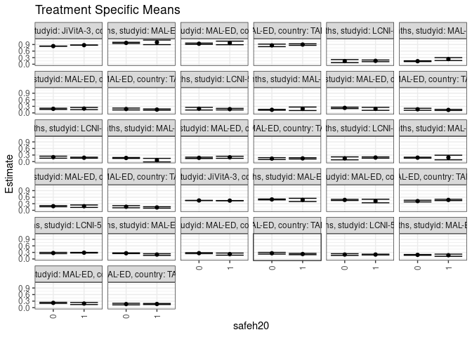

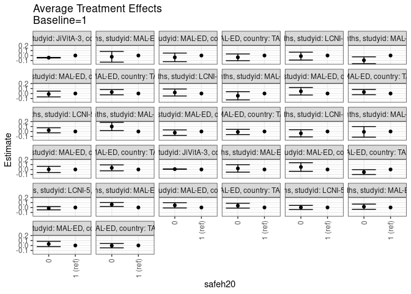

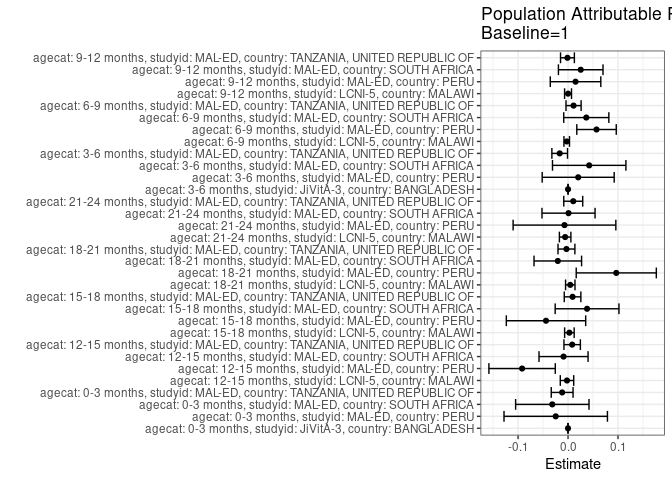

## Results Table

### Parameter: TSM

| agecat | studyid | country | intervention_level | baseline_level | estimate | ci_lower | ci_upper |
| --- | --- | --- | --- | --- | --- | --- | --- |
| 0-3 months | JiVitA-3 | BANGLADESH | 1 | NA | 0.8711253 | 0.8679699 | 0.8742807 |
| 0-3 months | JiVitA-3 | BANGLADESH | 0 | NA | 0.8269377 | 0.8228637 | 0.8310118 |
| 0-3 months | MAL-ED | PERU | 1 | NA | 0.9995029 | 0.8949353 | 1.1040704 |
| 0-3 months | MAL-ED | PERU | 0 | NA | 0.9737640 | 0.9463811 | 1.0011468 |
| 0-3 months | MAL-ED | SOUTH AFRICA | 1 | NA | 0.9730759 | 0.8917820 | 1.0543699 |
| 0-3 months | MAL-ED | SOUTH AFRICA | 0 | NA | 0.9359832 | 0.9064594 | 0.9655069 |
| 0-3 months | MAL-ED | TANZANIA, UNITED REPUBLIC OF | 1 | NA | 0.8978711 | 0.8622170 | 0.9335253 |
| 0-3 months | MAL-ED | TANZANIA, UNITED REPUBLIC OF | 0 | NA | 0.8609942 | 0.8030415 | 0.9189469 |
| 3-6 months | JiVitA-3 | BANGLADESH | 1 | NA | 0.4413846 | 0.4383463 | 0.4444229 |
| 3-6 months | JiVitA-3 | BANGLADESH | 0 | NA | 0.4484426 | 0.4457210 | 0.4511642 |
| 3-6 months | MAL-ED | PERU | 1 | NA | 0.4745474 | 0.4020187 | 0.5470761 |
| 3-6 months | MAL-ED | PERU | 0 | NA | 0.4957646 | 0.4756878 | 0.5158415 |
| 3-6 months | MAL-ED | SOUTH AFRICA | 1 | NA | 0.4245386 | 0.3424607 | 0.5066166 |
| 3-6 months | MAL-ED | SOUTH AFRICA | 0 | NA | 0.4743563 | 0.4474706 | 0.5012421 |
| 3-6 months | MAL-ED | TANZANIA, UNITED REPUBLIC OF | 1 | NA | 0.4733750 | 0.4431281 | 0.5036220 |
| 3-6 months | MAL-ED | TANZANIA, UNITED REPUBLIC OF | 0 | NA | 0.4204066 | 0.3822989 | 0.4585144 |
| 6-9 months | LCNI-5 | MALAWI | 1 | NA | 0.2875378 | 0.2736065 | 0.3014691 |
| 6-9 months | LCNI-5 | MALAWI | 0 | NA | 0.2721459 | 0.2428671 | 0.3014247 |
| 6-9 months | MAL-ED | PERU | 1 | NA | 0.2023311 | 0.1644833 | 0.2401789 |
| 6-9 months | MAL-ED | PERU | 0 | NA | 0.2618651 | 0.2455768 | 0.2781534 |
| 6-9 months | MAL-ED | SOUTH AFRICA | 1 | NA | 0.2230796 | 0.1749712 | 0.2711880 |
| 6-9 months | MAL-ED | SOUTH AFRICA | 0 | NA | 0.2663893 | 0.2430927 | 0.2896859 |
| 6-9 months | MAL-ED | TANZANIA, UNITED REPUBLIC OF | 1 | NA | 0.2267437 | 0.1963333 | 0.2571541 |
| 6-9 months | MAL-ED | TANZANIA, UNITED REPUBLIC OF | 0 | NA | 0.2625721 | 0.2246537 | 0.3004905 |
| 9-12 months | LCNI-5 | MALAWI | 1 | NA | 0.2022314 | 0.1846684 | 0.2197945 |
| 9-12 months | LCNI-5 | MALAWI | 0 | NA | 0.2023840 | 0.1643817 | 0.2403863 |
| 9-12 months | MAL-ED | PERU | 1 | NA | 0.1723232 | 0.1222520 | 0.2223945 |
| 9-12 months | MAL-ED | PERU | 0 | NA | 0.1879670 | 0.1717185 | 0.2042154 |
| 9-12 months | MAL-ED | SOUTH AFRICA | 1 | NA | 0.1899344 | 0.1430001 | 0.2368687 |
| 9-12 months | MAL-ED | SOUTH AFRICA | 0 | NA | 0.2201304 | 0.1954045 | 0.2448564 |
| 9-12 months | MAL-ED | TANZANIA, UNITED REPUBLIC OF | 1 | NA | 0.1682332 | 0.1438349 | 0.1926314 |
| 9-12 months | MAL-ED | TANZANIA, UNITED REPUBLIC OF | 0 | NA | 0.1645224 | 0.1277985 | 0.2012463 |
| 12-15 months | LCNI-5 | MALAWI | 1 | NA | 0.1539586 | 0.1160070 | 0.1919103 |
| 12-15 months | LCNI-5 | MALAWI | 0 | NA | 0.1415989 | 0.0714692 | 0.2117286 |
| 12-15 months | MAL-ED | PERU | 1 | NA | 0.2334736 | 0.1667517 | 0.3001954 |
| 12-15 months | MAL-ED | PERU | 0 | NA | 0.1379933 | 0.1206783 | 0.1553083 |
| 12-15 months | MAL-ED | SOUTH AFRICA | 1 | NA | 0.1969891 | 0.1460280 | 0.2479502 |
| 12-15 months | MAL-ED | SOUTH AFRICA | 0 | NA | 0.1862936 | 0.1579363 | 0.2146510 |
| 12-15 months | MAL-ED | TANZANIA, UNITED REPUBLIC OF | 1 | NA | 0.1508537 | 0.1206201 | 0.1810872 |
| 12-15 months | MAL-ED | TANZANIA, UNITED REPUBLIC OF | 0 | NA | 0.1773863 | 0.1344043 | 0.2203683 |
| 15-18 months | LCNI-5 | MALAWI | 1 | NA | 0.1711589 | 0.1359549 | 0.2063630 |
| 15-18 months | LCNI-5 | MALAWI | 0 | NA | 0.1911572 | 0.1307860 | 0.2515284 |
| 15-18 months | MAL-ED | PERU | 1 | NA | 0.1874214 | 0.1072172 | 0.2676256 |
| 15-18 months | MAL-ED | PERU | 0 | NA | 0.1415552 | 0.1218013 | 0.1613092 |
| 15-18 months | MAL-ED | SOUTH AFRICA | 1 | NA | 0.1846306 | 0.1157233 | 0.2535378 |
| 15-18 months | MAL-ED | SOUTH AFRICA | 0 | NA | 0.2297641 | 0.1986652 | 0.2608630 |
| 15-18 months | MAL-ED | TANZANIA, UNITED REPUBLIC OF | 1 | NA | 0.1358982 | 0.1105142 | 0.1612822 |
| 15-18 months | MAL-ED | TANZANIA, UNITED REPUBLIC OF | 0 | NA | 0.1646301 | 0.1187226 | 0.2105377 |
| 18-21 months | LCNI-5 | MALAWI | 1 | NA | 0.1773684 | 0.1549475 | 0.1997893 |
| 18-21 months | LCNI-5 | MALAWI | 0 | NA | 0.2017680 | 0.1558895 | 0.2476465 |
| 18-21 months | MAL-ED | PERU | 1 | NA | 0.0653975 | -0.0157629 | 0.1465580 |
| 18-21 months | MAL-ED | PERU | 0 | NA | 0.1660201 | 0.1463857 | 0.1856545 |
| 18-21 months | MAL-ED | SOUTH AFRICA | 1 | NA | 0.1959997 | 0.1486953 | 0.2433041 |
| 18-21 months | MAL-ED | SOUTH AFRICA | 0 | NA | 0.1718820 | 0.1418615 | 0.2019025 |
| 18-21 months | MAL-ED | TANZANIA, UNITED REPUBLIC OF | 1 | NA | 0.1466499 | 0.1171000 | 0.1761999 |
| 18-21 months | MAL-ED | TANZANIA, UNITED REPUBLIC OF | 0 | NA | 0.1367818 | 0.0938323 | 0.1797313 |
| 21-24 months | LCNI-5 | MALAWI | 1 | NA | 0.1847513 | 0.1554463 | 0.2140562 |
| 21-24 months | LCNI-5 | MALAWI | 0 | NA | 0.1478276 | 0.0813334 | 0.2143218 |
| 21-24 months | MAL-ED | PERU | 1 | NA | 0.1869388 | 0.0820127 | 0.2918650 |
| 21-24 months | MAL-ED | PERU | 0 | NA | 0.1795172 | 0.1591318 | 0.1999026 |
| 21-24 months | MAL-ED | SOUTH AFRICA | 1 | NA | 0.1869026 | 0.1305843 | 0.2432209 |
| 21-24 months | MAL-ED | SOUTH AFRICA | 0 | NA | 0.1880055 | 0.1617967 | 0.2142144 |
| 21-24 months | MAL-ED | TANZANIA, UNITED REPUBLIC OF | 1 | NA | 0.1297935 | 0.0963833 | 0.1632038 |
| 21-24 months | MAL-ED | TANZANIA, UNITED REPUBLIC OF | 0 | NA | 0.1626386 | 0.1134605 | 0.2118166 |

### Parameter: E(Y)

| agecat | studyid | country | intervention_level | baseline_level | estimate | ci_lower | ci_upper |
| --- | --- | --- | --- | --- | --- | --- | --- |
| 0-3 months | JiVitA-3 | BANGLADESH | NA | NA | 0.8710534 | 0.8679738 | 0.8741329 |
| 0-3 months | MAL-ED | PERU | NA | NA | 0.9748614 | 0.9482620 | 1.0014607 |
| 0-3 months | MAL-ED | SOUTH AFRICA | NA | NA | 0.9415988 | 0.9136365 | 0.9695612 |
| 0-3 months | MAL-ED | TANZANIA, UNITED REPUBLIC OF | NA | NA | 0.8861087 | 0.8555112 | 0.9167061 |
| 3-6 months | JiVitA-3 | BANGLADESH | NA | NA | 0.4413913 | 0.4384220 | 0.4443605 |
| 3-6 months | MAL-ED | PERU | NA | NA | 0.4948529 | 0.4753805 | 0.5143254 |
| 3-6 months | MAL-ED | SOUTH AFRICA | NA | NA | 0.4668837 | 0.4408277 | 0.4929397 |
| 3-6 months | MAL-ED | TANZANIA, UNITED REPUBLIC OF | NA | NA | 0.4566833 | 0.4325348 | 0.4808318 |
| 6-9 months | LCNI-5 | MALAWI | NA | NA | 0.2849079 | 0.2723110 | 0.2975048 |
| 6-9 months | MAL-ED | PERU | NA | NA | 0.2593318 | 0.2435782 | 0.2750853 |
| 6-9 months | MAL-ED | SOUTH AFRICA | NA | NA | 0.2596104 | 0.2384684 | 0.2807524 |
| 6-9 months | MAL-ED | TANZANIA, UNITED REPUBLIC OF | NA | NA | 0.2377801 | 0.2136152 | 0.2619451 |
| 9-12 months | LCNI-5 | MALAWI | NA | NA | 0.2022567 | 0.1863082 | 0.2182053 |
| 9-12 months | MAL-ED | PERU | NA | NA | 0.1873440 | 0.1716106 | 0.2030773 |
| 9-12 months | MAL-ED | SOUTH AFRICA | NA | NA | 0.2153147 | 0.1931793 | 0.2374501 |
| 9-12 months | MAL-ED | TANZANIA, UNITED REPUBLIC OF | NA | NA | 0.1670684 | 0.1467422 | 0.1873945 |
| 12-15 months | LCNI-5 | MALAWI | NA | NA | 0.1518822 | 0.1181702 | 0.1855942 |
| 12-15 months | MAL-ED | PERU | NA | NA | 0.1415461 | 0.1245184 | 0.1585737 |
| 12-15 months | MAL-ED | SOUTH AFRICA | NA | NA | 0.1879898 | 0.1627929 | 0.2131868 |
| 12-15 months | MAL-ED | TANZANIA, UNITED REPUBLIC OF | NA | NA | 0.1591083 | 0.1343053 | 0.1839113 |
| 15-18 months | LCNI-5 | MALAWI | NA | NA | 0.1738706 | 0.1423337 | 0.2054074 |
| 15-18 months | MAL-ED | PERU | NA | NA | 0.1433364 | 0.1240576 | 0.1626152 |
| 15-18 months | MAL-ED | SOUTH AFRICA | NA | NA | 0.2227120 | 0.1942678 | 0.2511562 |
| 15-18 months | MAL-ED | TANZANIA, UNITED REPUBLIC OF | NA | NA | 0.1449507 | 0.1222652 | 0.1676362 |
| 18-21 months | LCNI-5 | MALAWI | NA | NA | 0.1818489 | 0.1616805 | 0.2020172 |
| 18-21 months | MAL-ED | PERU | NA | NA | 0.1619131 | 0.1425878 | 0.1812383 |
| 18-21 months | MAL-ED | SOUTH AFRICA | NA | NA | 0.1755205 | 0.1490254 | 0.2020155 |
| 18-21 months | MAL-ED | TANZANIA, UNITED REPUBLIC OF | NA | NA | 0.1434559 | 0.1191029 | 0.1678089 |
| 21-24 months | LCNI-5 | MALAWI | NA | NA | 0.1789517 | 0.1520986 | 0.2058049 |
| 21-24 months | MAL-ED | PERU | NA | NA | 0.1798026 | 0.1597891 | 0.1998162 |
| 21-24 months | MAL-ED | SOUTH AFRICA | NA | NA | 0.1878453 | 0.1639966 | 0.2116939 |
| 21-24 months | MAL-ED | TANZANIA, UNITED REPUBLIC OF | NA | NA | 0.1402078 | 0.1124924 | 0.1679233 |

### Parameter: ATE

| agecat | studyid | country | intervention_level | baseline_level | estimate | ci_lower | ci_upper |
| --- | --- | --- | --- | --- | --- | --- | --- |
| 0-3 months | JiVitA-3 | BANGLADESH | 1 | 1 | 0.0000000 | 0.0000000 | 0.0000000 |
| 0-3 months | JiVitA-3 | BANGLADESH | 0 | 1 | -0.0441876 | -0.0492964 | -0.0390787 |
| 0-3 months | MAL-ED | PERU | 1 | 1 | 0.0000000 | 0.0000000 | 0.0000000 |
| 0-3 months | MAL-ED | PERU | 0 | 1 | -0.0257389 | -0.1338324 | 0.0823545 |
| 0-3 months | MAL-ED | SOUTH AFRICA | 1 | 1 | 0.0000000 | 0.0000000 | 0.0000000 |
| 0-3 months | MAL-ED | SOUTH AFRICA | 0 | 1 | -0.0370928 | -0.1235818 | 0.0493963 |
| 0-3 months | MAL-ED | TANZANIA, UNITED REPUBLIC OF | 1 | 1 | 0.0000000 | 0.0000000 | 0.0000000 |
| 0-3 months | MAL-ED | TANZANIA, UNITED REPUBLIC OF | 0 | 1 | -0.0368770 | -0.1049191 | 0.0311652 |
| 3-6 months | JiVitA-3 | BANGLADESH | 1 | 1 | 0.0000000 | 0.0000000 | 0.0000000 |
| 3-6 months | JiVitA-3 | BANGLADESH | 0 | 1 | 0.0070580 | 0.0031670 | 0.0109490 |
| 3-6 months | MAL-ED | PERU | 1 | 1 | 0.0000000 | 0.0000000 | 0.0000000 |
| 3-6 months | MAL-ED | PERU | 0 | 1 | 0.0212172 | -0.0540390 | 0.0964734 |
| 3-6 months | MAL-ED | SOUTH AFRICA | 1 | 1 | 0.0000000 | 0.0000000 | 0.0000000 |
| 3-6 months | MAL-ED | SOUTH AFRICA | 0 | 1 | 0.0498177 | -0.0365514 | 0.1361868 |
| 3-6 months | MAL-ED | TANZANIA, UNITED REPUBLIC OF | 1 | 1 | 0.0000000 | 0.0000000 | 0.0000000 |
| 3-6 months | MAL-ED | TANZANIA, UNITED REPUBLIC OF | 0 | 1 | -0.0529684 | -0.1016210 | -0.0043158 |
| 6-9 months | LCNI-5 | MALAWI | 1 | 1 | 0.0000000 | 0.0000000 | 0.0000000 |
| 6-9 months | LCNI-5 | MALAWI | 0 | 1 | -0.0153920 | -0.0478161 | 0.0170322 |
| 6-9 months | MAL-ED | PERU | 1 | 1 | 0.0000000 | 0.0000000 | 0.0000000 |
| 6-9 months | MAL-ED | PERU | 0 | 1 | 0.0595340 | 0.0183300 | 0.1007380 |
| 6-9 months | MAL-ED | SOUTH AFRICA | 1 | 1 | 0.0000000 | 0.0000000 | 0.0000000 |
| 6-9 months | MAL-ED | SOUTH AFRICA | 0 | 1 | 0.0433097 | -0.0101426 | 0.0967620 |
| 6-9 months | MAL-ED | TANZANIA, UNITED REPUBLIC OF | 1 | 1 | 0.0000000 | 0.0000000 | 0.0000000 |
| 6-9 months | MAL-ED | TANZANIA, UNITED REPUBLIC OF | 0 | 1 | 0.0358284 | -0.0127781 | 0.0844350 |
| 9-12 months | LCNI-5 | MALAWI | 1 | 1 | 0.0000000 | 0.0000000 | 0.0000000 |
| 9-12 months | LCNI-5 | MALAWI | 0 | 1 | 0.0001526 | -0.0417119 | 0.0420171 |
| 9-12 months | MAL-ED | PERU | 1 | 1 | 0.0000000 | 0.0000000 | 0.0000000 |
| 9-12 months | MAL-ED | PERU | 0 | 1 | 0.0156437 | -0.0369979 | 0.0682854 |
| 9-12 months | MAL-ED | SOUTH AFRICA | 1 | 1 | 0.0000000 | 0.0000000 | 0.0000000 |
| 9-12 months | MAL-ED | SOUTH AFRICA | 0 | 1 | 0.0301961 | -0.0228530 | 0.0832451 |
| 9-12 months | MAL-ED | TANZANIA, UNITED REPUBLIC OF | 1 | 1 | 0.0000000 | 0.0000000 | 0.0000000 |
| 9-12 months | MAL-ED | TANZANIA, UNITED REPUBLIC OF | 0 | 1 | -0.0037108 | -0.0478007 | 0.0403791 |
| 12-15 months | LCNI-5 | MALAWI | 1 | 1 | 0.0000000 | 0.0000000 | 0.0000000 |
| 12-15 months | LCNI-5 | MALAWI | 0 | 1 | -0.0123597 | -0.0920999 | 0.0673805 |
| 12-15 months | MAL-ED | PERU | 1 | 1 | 0.0000000 | 0.0000000 | 0.0000000 |
| 12-15 months | MAL-ED | PERU | 0 | 1 | -0.0954802 | -0.1644122 | -0.0265483 |
| 12-15 months | MAL-ED | SOUTH AFRICA | 1 | 1 | 0.0000000 | 0.0000000 | 0.0000000 |
| 12-15 months | MAL-ED | SOUTH AFRICA | 0 | 1 | -0.0106955 | -0.0690150 | 0.0476241 |
| 12-15 months | MAL-ED | TANZANIA, UNITED REPUBLIC OF | 1 | 1 | 0.0000000 | 0.0000000 | 0.0000000 |
| 12-15 months | MAL-ED | TANZANIA, UNITED REPUBLIC OF | 0 | 1 | 0.0265326 | -0.0260175 | 0.0790828 |
| 15-18 months | LCNI-5 | MALAWI | 1 | 1 | 0.0000000 | 0.0000000 | 0.0000000 |
| 15-18 months | LCNI-5 | MALAWI | 0 | 1 | 0.0199982 | -0.0498875 | 0.0898840 |
| 15-18 months | MAL-ED | PERU | 1 | 1 | 0.0000000 | 0.0000000 | 0.0000000 |
| 15-18 months | MAL-ED | PERU | 0 | 1 | -0.0458662 | -0.1284672 | 0.0367349 |
| 15-18 months | MAL-ED | SOUTH AFRICA | 1 | 1 | 0.0000000 | 0.0000000 | 0.0000000 |
| 15-18 months | MAL-ED | SOUTH AFRICA | 0 | 1 | 0.0451336 | -0.0304664 | 0.1207335 |
| 15-18 months | MAL-ED | TANZANIA, UNITED REPUBLIC OF | 1 | 1 | 0.0000000 | 0.0000000 | 0.0000000 |
| 15-18 months | MAL-ED | TANZANIA, UNITED REPUBLIC OF | 0 | 1 | 0.0287319 | -0.0237262 | 0.0811900 |
| 18-21 months | LCNI-5 | MALAWI | 1 | 1 | 0.0000000 | 0.0000000 | 0.0000000 |
| 18-21 months | LCNI-5 | MALAWI | 0 | 1 | 0.0243996 | -0.0266645 | 0.0754636 |
| 18-21 months | MAL-ED | PERU | 1 | 1 | 0.0000000 | 0.0000000 | 0.0000000 |
| 18-21 months | MAL-ED | PERU | 0 | 1 | 0.1006226 | 0.0171209 | 0.1841242 |
| 18-21 months | MAL-ED | SOUTH AFRICA | 1 | 1 | 0.0000000 | 0.0000000 | 0.0000000 |
| 18-21 months | MAL-ED | SOUTH AFRICA | 0 | 1 | -0.0241177 | -0.0801439 | 0.0319086 |
| 18-21 months | MAL-ED | TANZANIA, UNITED REPUBLIC OF | 1 | 1 | 0.0000000 | 0.0000000 | 0.0000000 |
| 18-21 months | MAL-ED | TANZANIA, UNITED REPUBLIC OF | 0 | 1 | -0.0098681 | -0.0620012 | 0.0422650 |
| 21-24 months | LCNI-5 | MALAWI | 1 | 1 | 0.0000000 | 0.0000000 | 0.0000000 |
| 21-24 months | LCNI-5 | MALAWI | 0 | 1 | -0.0369237 | -0.1095891 | 0.0357417 |
| 21-24 months | MAL-ED | PERU | 1 | 1 | 0.0000000 | 0.0000000 | 0.0000000 |
| 21-24 months | MAL-ED | PERU | 0 | 1 | -0.0074216 | -0.1143097 | 0.0994665 |
| 21-24 months | MAL-ED | SOUTH AFRICA | 1 | 1 | 0.0000000 | 0.0000000 | 0.0000000 |
| 21-24 months | MAL-ED | SOUTH AFRICA | 0 | 1 | 0.0011029 | -0.0610151 | 0.0632210 |
| 21-24 months | MAL-ED | TANZANIA, UNITED REPUBLIC OF | 1 | 1 | 0.0000000 | 0.0000000 | 0.0000000 |
| 21-24 months | MAL-ED | TANZANIA, UNITED REPUBLIC OF | 0 | 1 | 0.0328451 | -0.0266085 | 0.0922986 |

### Parameter: PAR

| agecat | studyid | country | intervention_level | baseline_level | estimate | ci_lower | ci_upper |
| --- | --- | --- | --- | --- | --- | --- | --- |
| 0-3 months | JiVitA-3 | BANGLADESH | 1 | NA | -0.0000719 | -0.0002041 | 0.0000603 |
| 0-3 months | MAL-ED | PERU | 1 | NA | -0.0246415 | -0.1281283 | 0.0788452 |
| 0-3 months | MAL-ED | SOUTH AFRICA | 1 | NA | -0.0314771 | -0.1048907 | 0.0419364 |
| 0-3 months | MAL-ED | TANZANIA, UNITED REPUBLIC OF | 1 | NA | -0.0117625 | -0.0335785 | 0.0100535 |
| 3-6 months | JiVitA-3 | BANGLADESH | 1 | NA | 0.0000067 | -0.0000911 | 0.0001044 |
| 3-6 months | MAL-ED | PERU | 1 | NA | 0.0203056 | -0.0517189 | 0.0923300 |
| 3-6 months | MAL-ED | SOUTH AFRICA | 1 | NA | 0.0423450 | -0.0311033 | 0.1157934 |
| 3-6 months | MAL-ED | TANZANIA, UNITED REPUBLIC OF | 1 | NA | -0.0166917 | -0.0323402 | -0.0010432 |
| 6-9 months | LCNI-5 | MALAWI | 1 | NA | -0.0026299 | -0.0081910 | 0.0029311 |
| 6-9 months | MAL-ED | PERU | 1 | NA | 0.0570006 | 0.0175200 | 0.0964813 |
| 6-9 months | MAL-ED | SOUTH AFRICA | 1 | NA | 0.0365308 | -0.0086011 | 0.0816627 |
| 6-9 months | MAL-ED | TANZANIA, UNITED REPUBLIC OF | 1 | NA | 0.0110364 | -0.0040927 | 0.0261656 |
| 9-12 months | LCNI-5 | MALAWI | 1 | NA | 0.0000253 | -0.0069154 | 0.0069660 |
| 9-12 months | MAL-ED | PERU | 1 | NA | 0.0150207 | -0.0355261 | 0.0655676 |
| 9-12 months | MAL-ED | SOUTH AFRICA | 1 | NA | 0.0253803 | -0.0192311 | 0.0699917 |
| 9-12 months | MAL-ED | TANZANIA, UNITED REPUBLIC OF | 1 | NA | -0.0011648 | -0.0150065 | 0.0126769 |
| 12-15 months | LCNI-5 | MALAWI | 1 | NA | -0.0020764 | -0.0154975 | 0.0113446 |
| 12-15 months | MAL-ED | PERU | 1 | NA | -0.0919275 | -0.1583387 | -0.0255163 |
| 12-15 months | MAL-ED | SOUTH AFRICA | 1 | NA | -0.0089993 | -0.0580725 | 0.0400740 |
| 12-15 months | MAL-ED | TANZANIA, UNITED REPUBLIC OF | 1 | NA | 0.0082546 | -0.0081733 | 0.0246825 |
| 15-18 months | LCNI-5 | MALAWI | 1 | NA | 0.0027116 | -0.0068453 | 0.0122685 |
| 15-18 months | MAL-ED | PERU | 1 | NA | -0.0440850 | -0.1234875 | 0.0353175 |
| 15-18 months | MAL-ED | SOUTH AFRICA | 1 | NA | 0.0380814 | -0.0257423 | 0.1019052 |
| 15-18 months | MAL-ED | TANZANIA, UNITED REPUBLIC OF | 1 | NA | 0.0090525 | -0.0075701 | 0.0256751 |
| 18-21 months | LCNI-5 | MALAWI | 1 | NA | 0.0044805 | -0.0049368 | 0.0138977 |
| 18-21 months | MAL-ED | PERU | 1 | NA | 0.0965155 | 0.0163734 | 0.1766577 |
| 18-21 months | MAL-ED | SOUTH AFRICA | 1 | NA | -0.0204792 | -0.0680663 | 0.0271078 |
| 18-21 months | MAL-ED | TANZANIA, UNITED REPUBLIC OF | 1 | NA | -0.0031940 | -0.0200798 | 0.0136917 |
| 21-24 months | LCNI-5 | MALAWI | 1 | NA | -0.0057995 | -0.0172924 | 0.0056933 |
| 21-24 months | MAL-ED | PERU | 1 | NA | -0.0071362 | -0.1099134 | 0.0956410 |
| 21-24 months | MAL-ED | SOUTH AFRICA | 1 | NA | 0.0009427 | -0.0521497 | 0.0540350 |
| 21-24 months | MAL-ED | TANZANIA, UNITED REPUBLIC OF | 1 | NA | 0.0104143 | -0.0085532 | 0.0293817 |